# Bolivia Vota

Este documento resume nuestros intentos de encontrar evidencia de alteración sistemática de votos durante las Elecciones Generales en Bolivia del 20 de Octubre 2019. Las bases de datos que estudiamos fueron obtenidas en el sitio del Órgano Electoral Plurinacional (OEP).

Para este análisis, se consideraron dos Bases de Datos:

- Los resultados del conteo rápido obtenidos el Martes 22 de Octubre de 2019 a las 20:38:53 (GMT-4) a la cual nos referimos como la muestra **TREP**.
- Resultados del Cómputo Final de Votos, obtenido el Viernes 25 de Octubre de 2019 a la 01:40:43(GMT-4). Nos referimos a esta muestra como **PRES**.

Esta exploración concierne solamente la elección para Presidente y Vicepresidente del Estado Plurinacional

# Comparación entre Votos Válidos y Agregación de Votos entre partidos y Categorías

Empezamos esta exploración considerando la muestra **PRES** con el objetivo de comparar las siguientes variables:

- `Votos.Válidos` : Variable disponible en la Base de Datos original y que indica el número total de votos válidos emitidos (i.e. por los partidos) en cada Mesa electoral.
- `Votos.Partidos`: Una variable creada a partir de la agregación (suma) de los votos emitidos a cada partido en cada mesa.

Se espera que la diferencia `Votos.Partidos - Votos.Válidos = 0` en todas las mesas de votación. Las mesas donde estas cantidades divergen son suscetibles de alteración fraudulenta.

Estas divergencias varían de la manera descrita en la siguiente tabla:

| Estadístico | Valor |
| --- | --- |
| Min | -109.00 |
| 1st Quartile | -8.00 |
| Median | -2.00 |
| Mean | -0.11 |
| 3rd Quartile | 1.00 |
| Max | 209.00 |

La Mediana y el Promedio de votos ‘perdidos’ son negativos, lo cual indicaría la posibilidad que hubiera una *supresión* de votos, i.e. Pérdida de votos en favor de algún candidato.

A este punto, corresponde analizar la posibildad que exista favoritismo para el partido de gobierno MAS-IPSP. Se pueden establecer los siguientes escenarios.

- **Mesas con votos *perdidos***: Los votos perdidos corresponden a CC y hacen que el MAS-IPSP se declare ganador en la mesa.
- **Mesas con votos *aumentados***: los votos aumentados van a MAS-IPSP y hacen que se declare ganador en esa mesa.

En el gráfico siguiente, reportamos estimaciones de la probabilidad condicional que cada partido gane una mesa sospechosa de alteración (barras grises), i.e.
$$\widehat{P}(\text{Partido Ganador} \ | \ \text{Mesa Sospechosa})
=
\frac{\# \text{Partido Ganador & Mesa Sospechosa}}
{\# \text{Mesa Sospechosa}}$$
y las proporciones de mesas ganadas por cada partido en la muestra completa (barras de colores)

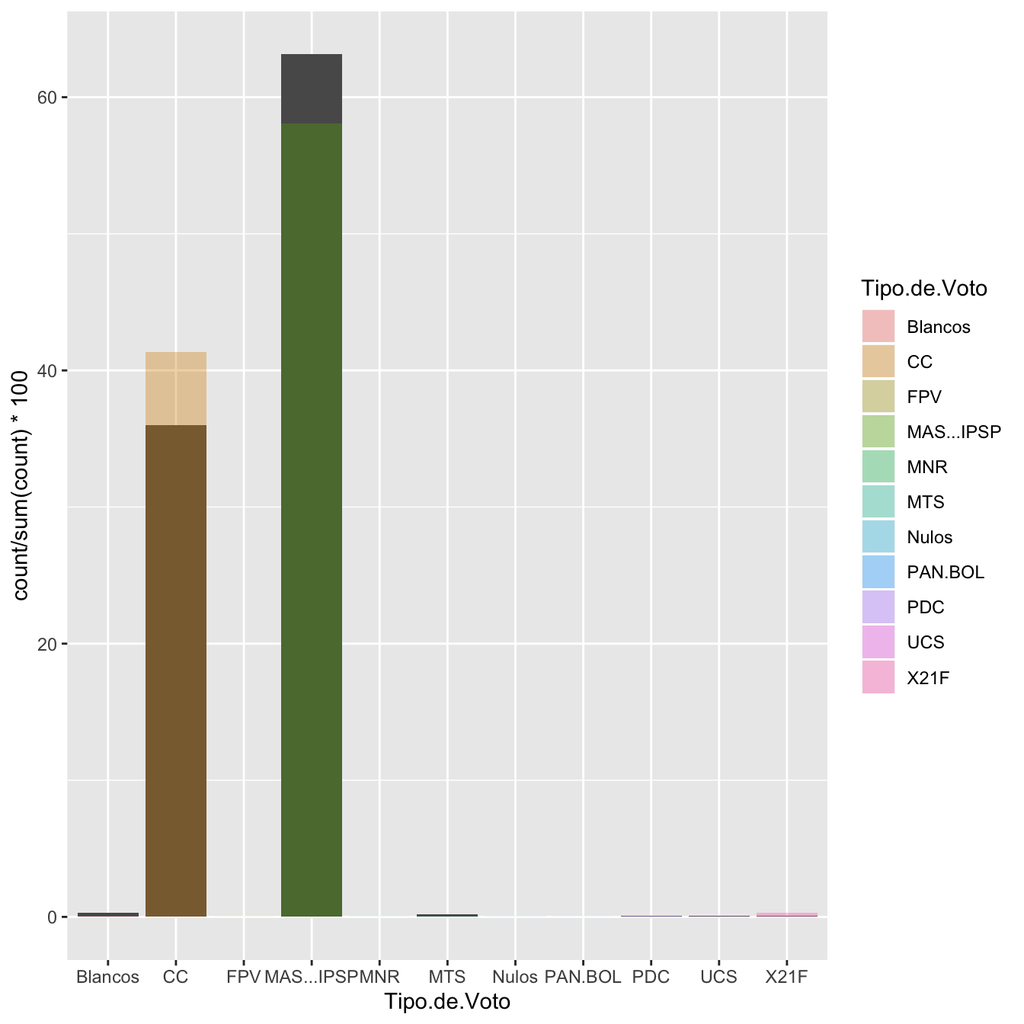

El gráfico muestra una diferencia importante entre dichas probabilidades. A este punto, podemos efectuar un test de ajuste. Para evitar problemas, se pueden aglomerar las mesas ganadoras de los otros partidos en una categoría llamada “otros ganadores”. Sin embargo, como se puede ver en los siguientes resultados, este test no rechaza la Hipótesis de igualdad de ambas distribuciones. Además, la implementación advierte sobre la poca fiabilidad del resultado, dado que la categoría agregada no tiene muchas observaciones.

```
##
##  Pearson's Chi-squared test
##
## data:  ap_sosp and ap_pres
## X-squared = 6, df = 4, p-value = 0.1991
```

Further verification of this hypothesis namely requiring seeing whether the suppresed/increased votes per booth were indeed **penalizing for CC and beneficial to MAS-IPSP** require a comparison between the **PRES** and **TREP** samples.

## Comparison between rapid counting and full report of the election results : the **TREP** vs. **PRES** samples.

The summary goes as follows:

| Estadístico | Valor |
| --- | --- |
| Min | -115.00 |
| 1st Quartile | -9.00 |
| Median | -3.00 |
| Mean | -1.55 |
| 3rd Quartile | 1.00 |
| Max | 213.00 |

More votes are negatively corrected in this sample

We now focus on the booths where the results of the vote differ, i.e. those that experience ‘alterations’ in the words of Villegas. Below is a plot that shows the sense of the alterations (increase or supresion) for the different parties.

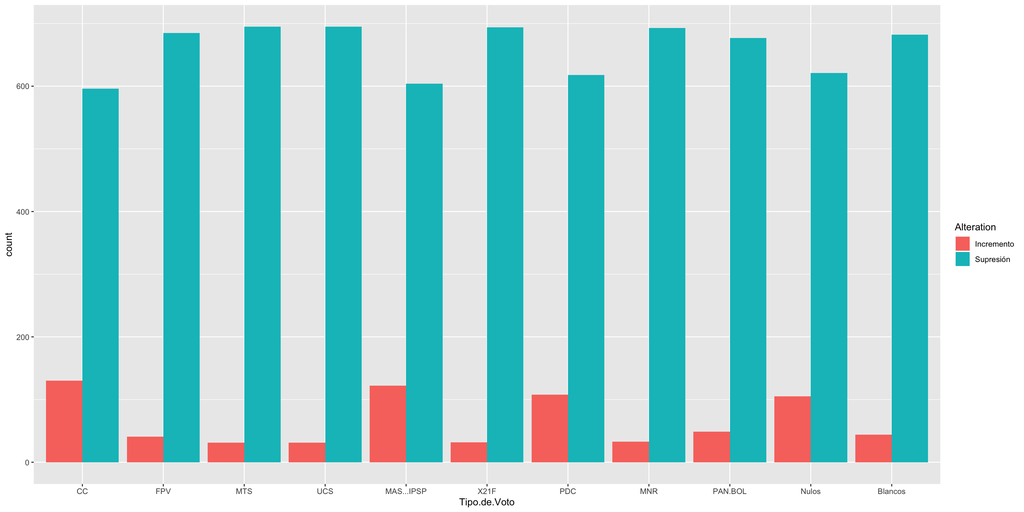

The plot shows that all the parties show more instances where their votes were reduced in the final computation. The computation was corrected with an increase in less cases.

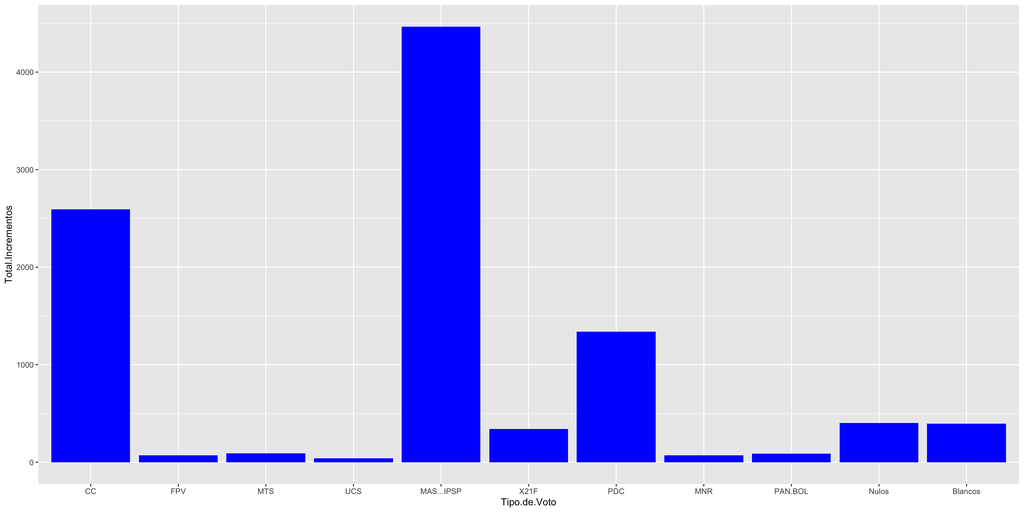

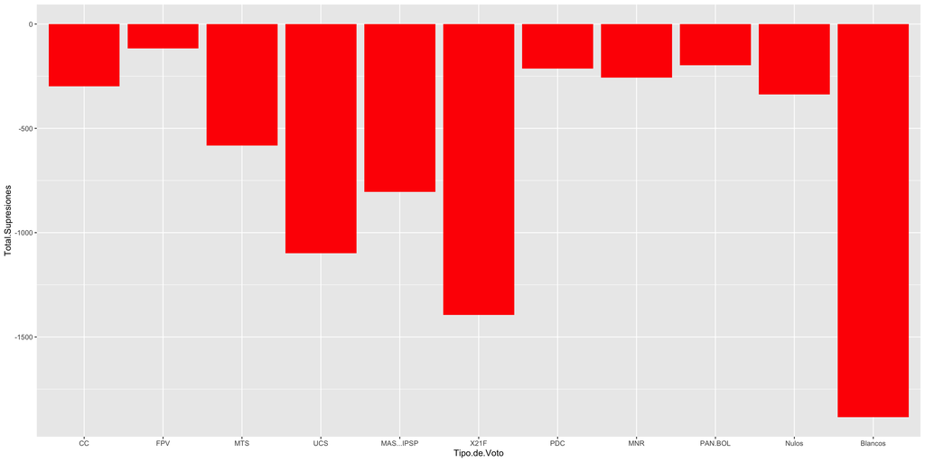

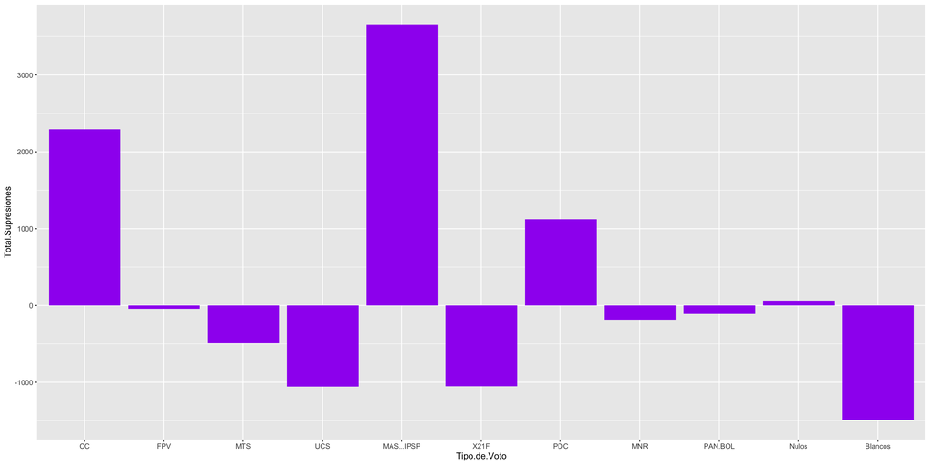

Una hipótesis que se puede manejar a este punto es la transferencia de votos, i.e. que los votos disminuidos a CC correspondan a algún incremento en los votos del MAS-IPSP o se transformen en Nulos o Blancos. A continuación una tabulación de las proporciones de esos escenarios, por el momento **sin consideración de la cantidad de votos transferidos**:

### Transferencia de CC a MAS-IPSP

```
##            BeneficiaMAS
## BeneficiaCC  Aumentan   Pierden
##    Aumentan  7.851240 10.055096
##    Pierden   8.953168 73.140496
```

Aproximadamente 8.95% de instancias de transferencia de votos. 10.06% de instancias en el otro sentido

### Transferencia de CC a Blancos

```
##            BeneficiaBlancos
## BeneficiaCC  Aumentan   Pierden
##    Aumentan  1.101928 16.804408
##    Pierden   4.958678 77.134986
```

Aproximadamente 4.96% de instancias de votos transpuestos a blancos. 16.8% en el otro sentido.

### Transferencia de CC a Nulos

```
##            BeneficiaNulos
## BeneficiaCC  Aumentan   Pierden
##    Aumentan  3.719008 14.187328
##    Pierden  10.743802 71.349862
```

Aproximadamente 10.74% de instancias de votos transpuestos anulados. 14.19% en el otro sentido.

### Transferencia de Blancos a MAS-IPSP

```
##             BeneficiaBlancos
## BeneficiaMAS  Aumentan   Pierden
##     Aumentan  1.101928 15.702479
##     Pierden   4.958678 78.236915
```

### Transferencia de Nulos a MAS-IPSP

```
##             BeneficiaNulos
## BeneficiaMAS  Aumentan   Pierden
##     Aumentan  4.269972 12.534435
##     Pierden  10.192837 73.002755
```

Next step is checking the **amounts**, but I’m a bit tired for that.

## Overviewing voting per Polling Districts

In this part, we try to check whether there is a difference between the results of voting at each booth within a precint and the results of the precint. One would expect that the distribution of the former is somehow reflective of the latter. This can be assessed graphically or via testing procedures with the respective corrections.

However, booths with a small amount of voters:

1. Could have a problem reflecting the distribution of the precint as they are small samples.
2. Hinder the statistical testing process.

### Some Examples

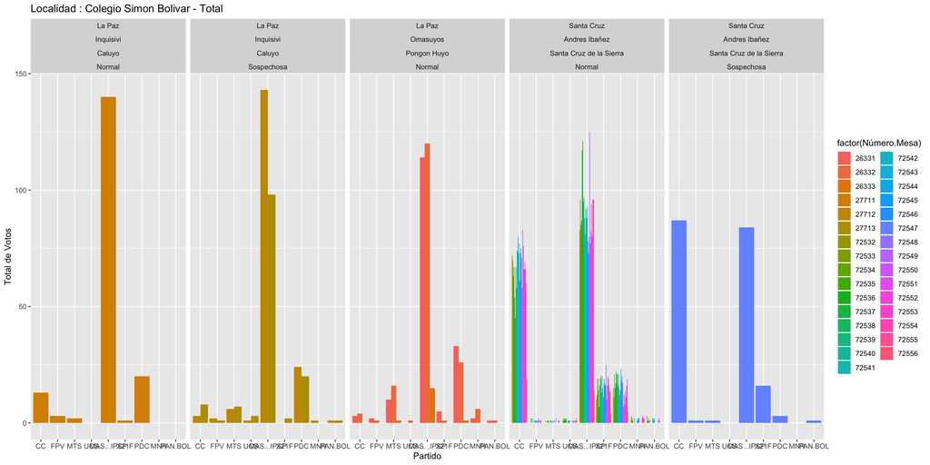

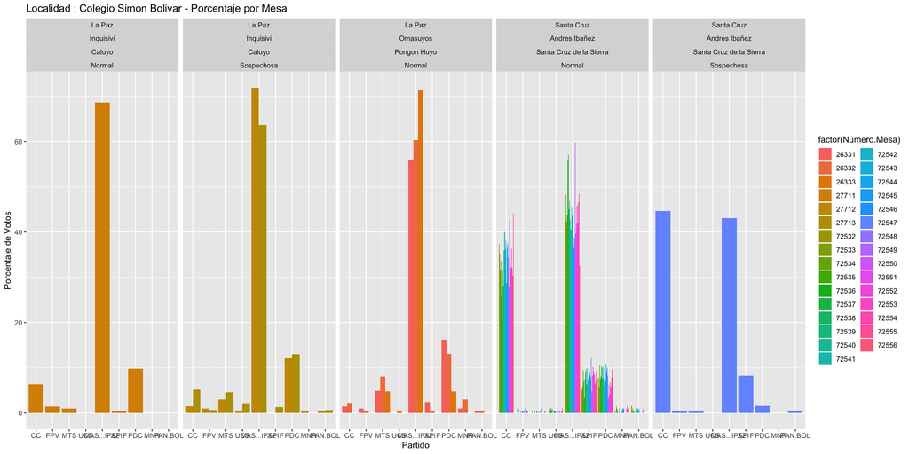

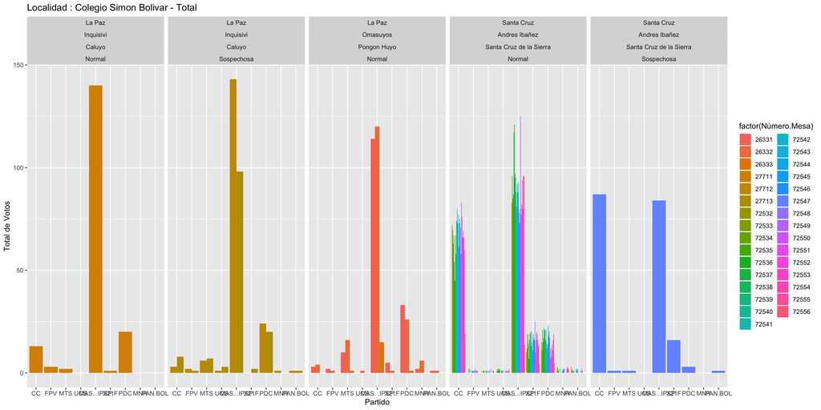

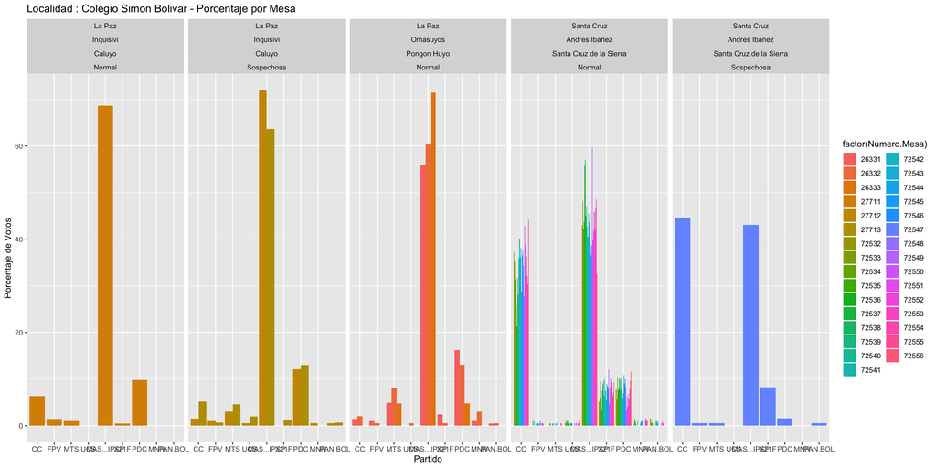